# Incarceration Trends

Evan Waara

2022-05-20

## Introduction

The data I am analyzing shows incarceration data for each county over time. I have chosen to analyze specifically the differences of black prison population rates compared to white rates since 2010 for each state. I am looking to illustrate how the criminal justice system is arresting black people at a disproportionately high rate. The original data set contains over 15,000 rows and 121 columns. to narrow the data down I decided to start tracking in 2010. I also narrowed it down to the columns state, year, average rate of prisoners that are Black, and average rate of prisoners that are White. This left me with 459 rows and 4 columns.

## Summary of the dataset

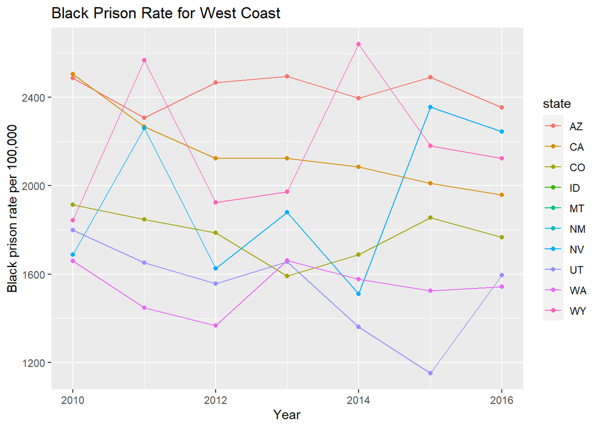

# Description

This graph shows the average black prison population per 100,000 residents of each state. The data does not show any significant trends other than the prison rate varies a lot.

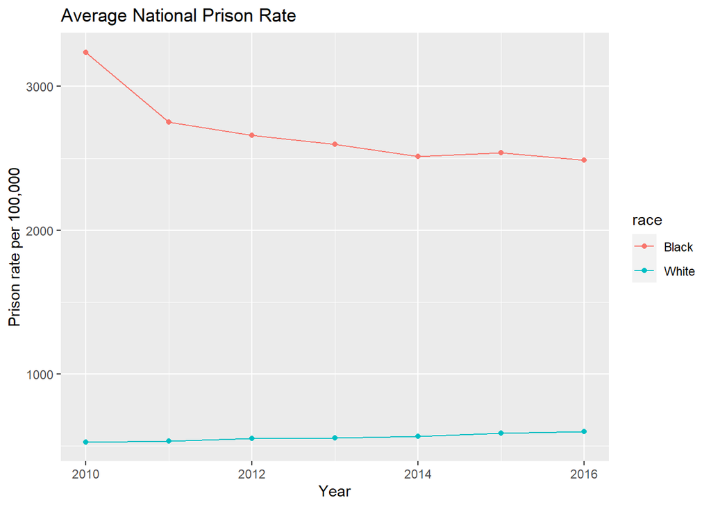

#Description This graph shows the national average prison population for Black and White people. This shows the huge disparity between Black and White incarceration. The Black prison rate is on a downward trend which might indicate improvement to the US criminal justice system

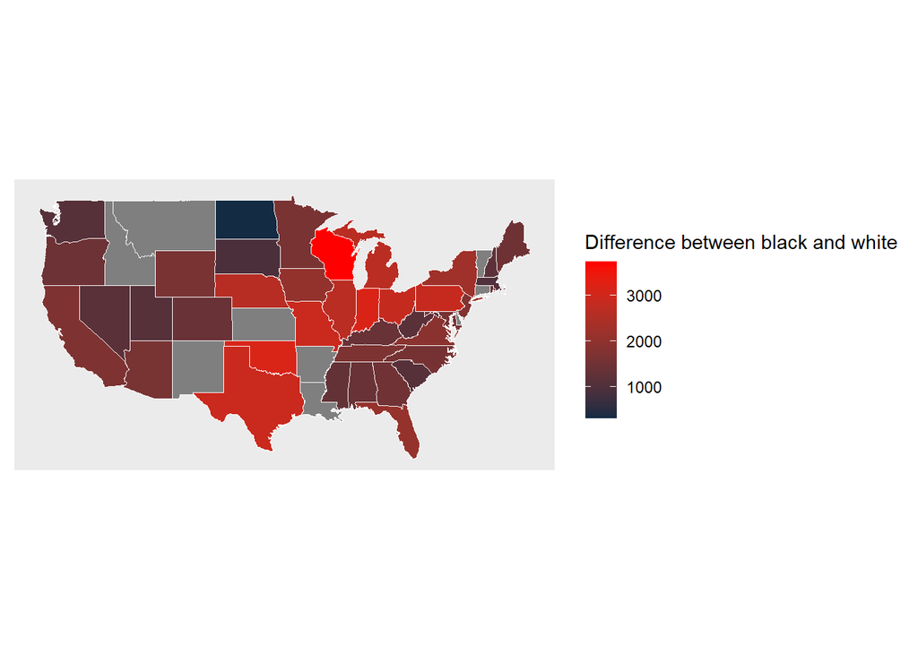

#Description This map highlights the states with a large difference in prison population rates between Black and White people. The brighter red states have a larger discrepancy between Black prison rates and White prison rates.